# Dickey Fuller Test

```python
# Pandas
import pandas as pd
print('Pandas: %s' % pd.__version__)

# Numpy
import numpy as np
print('Numpy: %s' % np.__version__)

# Statsmodels
import statsmodels.api as sm
from statsmodels.tsa.api import VAR
print('Statsmodels: %s' % sm.__version__)

#
from scipy.interpolate import interp1d

import matplotlib.pyplot as plt

from matplotlib.pyplot import figure

pd.options.display.max_rows = 2500
```

```
Pandas: 1.1.3
Numpy: 1.19.2
Statsmodels: 0.11.1
```

```python
df = pd.read_csv("CapstoneMainDF.csv")
productsDF = pd.read_csv("ProductsDF.csv", encoding = None)

df.columns = map(str.lower, df.columns)
```

```python
# impute item names
productdict = dict(zip(productsDF.Item_ID, productsDF.Item_Desc))
df["product_name"] = df.item_id
df.product_name = df.product_name.map(productdict)
df['date'] = pd.to_datetime(df['date'])

display(df.product_name.head(10))
```

```
0    D*WRI STARBURST 6z GMIBRST DUOS BAG
1           I*MAR KG 3.02z TWIX DRK CHOC
2             HER REESES FAST BREAK 1.8z
3         TRKR SNK 5z SOUR NEON WORM BAG
4                      HER ALMD JOY 1.6z
5         D*HARIBO GMI 5z HAPPY COLA BAG
6             TRKR SNK 5z PEACH RING BAG
7                      WRI ORBIT SWT MNT
8            D*HER KIT KAT WHT CHOC 1.5z
9                     I*MAR M&M PB 1.63z
Name: product_name, dtype: object
```

```python
#create new project data set
projectdf = df.loc[(df["project"]!="NONE")]
display(projectdf.head())
print("Format of ProjectDF subset = ", format(projectdf.shape))
```

|  | unnamed: 0 | site_id | item_id | date | quantity_sold | sales | location_id | open_date | sq_footage | locale | maxtemp | mintemp | fiscal_period | periodic_gbv | current_gbv | mpds | project | product_name |
| --- | --- | --- | --- | --- | --- | --- | --- | --- | --- | --- | --- | --- | --- | --- | --- | --- | --- | --- |
| 514663 | 514664 | 516 | -12284 | 2019-01-25 | 1 | 1.39 | 516 | 2015-12-01 | 5046 | SUBURBAN/RESIDENTIAL | 39.01 | 26.5 | 201901 | 3976482 | 3999290 | 12 | Program Addition | HER REESES FAST BREAK 1.8z |
| 514674 | 514675 | 516 | -28661 | 2019-01-25 | 5 | 8.45 | 516 | 2015-12-01 | 5046 | SUBURBAN/RESIDENTIAL | 39.01 | 26.5 | 201901 | 3976482 | 3999290 | 12 | Program Addition | KDSM DUBBLE BUBBLE MINI GUMBL |
| 514679 | 514680 | 516 | -32903 | 2019-01-25 | 2 | 3.98 | 516 | 2015-12-01 | 5046 | SUBURBAN/RESIDENTIAL | 39.01 | 26.5 | 201901 | 3976482 | 3999290 | 12 | Program Addition | HER KG WHATCHAMACALLIT 2.6z |
| 514688 | 514689 | 516 | -12270 | 2019-01-25 | 1 | 1.39 | 516 | 2015-12-01 | 5046 | SUBURBAN/RESIDENTIAL | 39.01 | 26.5 | 201901 | 3976482 | 3999290 | 12 | Program Addition | HER REG REESES TAKE 5 BAR 1.5z |
| 514701 | 514702 | 516 | -44543 | 2019-01-25 | 3 | 8.97 | 516 | 2015-12-01 | 5046 | SUBURBAN/RESIDENTIAL | 39.01 | 26.5 | 201901 | 3976482 | 3999290 | 12 | Program Addition | WRI KG EXTRA PPRMNT MGPK |

```
Format of ProjectDF subset =  (270, 18)
```

```python
# Remove Project from DF
df = df.loc[(df["project"]=="NONE")]
print("Format of DF subset = ", format(df.shape))
```

```
Format of DF subset =  (1351854, 18)
```

```python
#Imputation of Temperature
mintemp_bu = df['mintemp']
maxtemp_bu = df['maxtemp']


df['mintemp'].interpolate(method='linear', inplace=True)
df['maxtemp'].interpolate(method='linear', inplace=True)
```

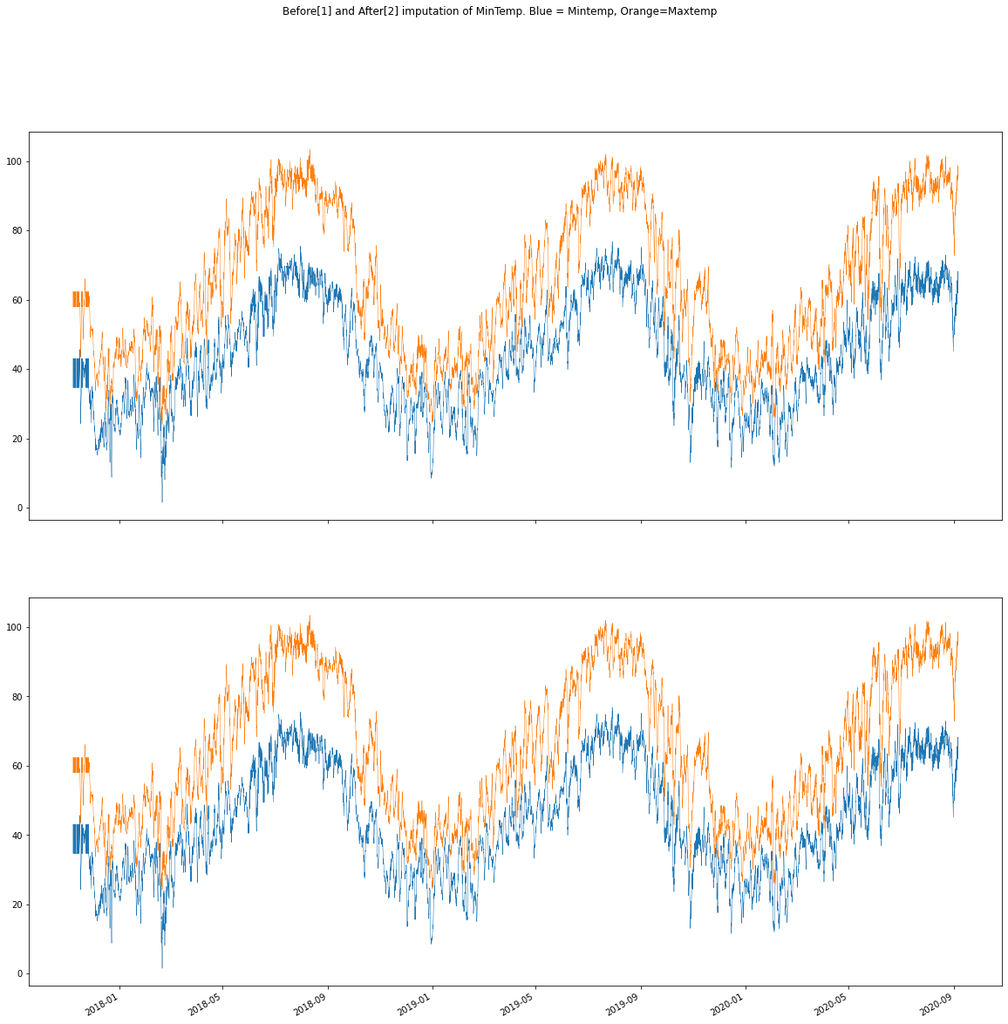

```python
fig, (ax1,ax2) = plt.subplots(2, sharex=True,figsize=(20, 20))
fig.autofmt_xdate()
fig.suptitle('Before[1] and After[2] imputation of MinTemp. Blue = Mintemp, Orange=Maxtemp')
ax1.plot(df["date"], df["mintemp"], alpha = 1, linewidth=.5)
ax1.plot(df["date"], df["maxtemp"], alpha = 1, linewidth=.5)
ax2.plot(df["date"], mintemp_bu, alpha = 1, linewidth=.5)
ax2.plot(df["date"], maxtemp_bu, alpha = 1, linewidth=.5)
```

```python
#outlier detection
df["price"] = df["sales"] / df["quantity_sold"]
```

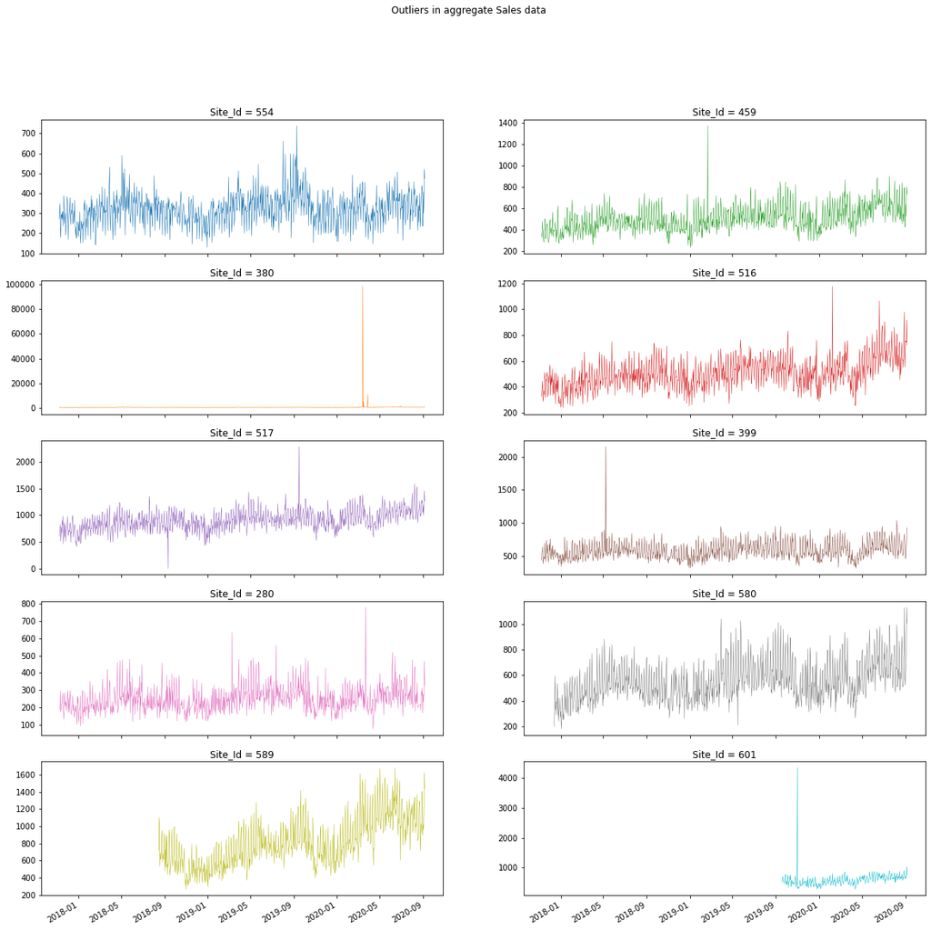

```python
z = df.groupby(["date","site_id"]).agg(daily_sales = pd.NamedAgg(column="sales", aggfunc = sum)).reset_index()
z["date"] = pd.to_datetime(z["date"])

f, axes =  plt.subplots(5, 2, figsize=(20, 20), sharex=True, sharey=False)
f.autofmt_xdate()
f.suptitle('Outliers in aggregate Sales data')
axes[0,0].plot(z["date"][z["site_id"]==554],z["daily_sales"][z["site_id"]==554],'tab:blue', linewidth=.5)
axes[0,0].set_title('Site_Id = 554')
axes[0,1].plot(z["date"][z["site_id"]==459],z["daily_sales"][z["site_id"]==459],'tab:green', linewidth=.5)
axes[0,1].set_title('Site_Id = 459')
axes[1,0].plot(z["date"][z["site_id"]==380],z["daily_sales"][z["site_id"]==380],'tab:orange', linewidth=.5)
axes[1,0].set_title('Site_Id = 380')
axes[1,1].plot(z["date"][z["site_id"]==516],z["daily_sales"][z["site_id"]==516],'tab:red', linewidth=.5)
axes[1,1].set_title('Site_Id = 516')
axes[2,0].plot(z["date"][z["site_id"]==517],z["daily_sales"][z["site_id"]==517],'tab:purple', linewidth=.5)
axes[2,0].set_title('Site_Id = 517')
axes[2,1].plot(z["date"][z["site_id"]==399],z["daily_sales"][z["site_id"]==399],'tab:brown', linewidth=.5)
axes[2,1].set_title('Site_Id = 399')
axes[3,0].plot(z["date"][z["site_id"]==280],z["daily_sales"][z["site_id"]==280],'tab:pink', linewidth=.5)
axes[3,0].set_title('Site_Id = 280')
axes[3,1].plot(z["date"][z["site_id"]==580],z["daily_sales"][z["site_id"]==580],'tab:gray', linewidth=.5)
axes[3,1].set_title('Site_Id = 580')
axes[4,0].plot(z["date"][z["site_id"]==589],z["daily_sales"][z["site_id"]==589],'tab:olive', linewidth=.5)
axes[4,0].set_title('Site_Id = 589')
axes[4,1].plot(z["date"][z["site_id"]==601],z["daily_sales"][z["site_id"]==601],'tab:cyan', linewidth=.5)
axes[4,1].set_title('Site_Id = 601')
```

```python
#most sold items and pre calculations
x = df.groupby(["date","product_name"]).agg(daily_sales = pd.NamedAgg(column="sales", aggfunc = sum),
                                            daily_quantity = pd.NamedAgg(column = "quantity_sold", aggfunc = sum)).reset_index()
x["date"] = pd.to_datetime(x["date"])

x2 = x.groupby(["product_name"]).agg(Total_sales = pd.NamedAgg(column = "daily_sales", aggfunc = sum),
                                    Total_quantity = pd.NamedAgg(column = "daily_quantity", aggfunc = sum),
                                    mean_daily_sales = pd.NamedAgg(column = "daily_sales", aggfunc = "mean"),
                                    mean_daily_quantity = pd.NamedAgg(column = "daily_quantity", aggfunc = "mean"),
                                    Transaction_days = pd.NamedAgg(column = "product_name", aggfunc = "count")).sort_values("Total_sales",ascending=False)

x2["Total_Avg_Price"] = x2["Total_sales"]/x2["Total_quantity"]
#x2 = x2.round(2)
x2.head(15)
```

| product_name | Total_sales | Total_quantity | mean_daily_sales | mean_daily_quantity | Transaction_days | Total_Avg_Price |
| --- | --- | --- | --- | --- | --- | --- |
| TTS TOOTSIE ROLL $.10 | 101973.70 | 47037 | 106.555590 | 49.150470 | 957 | 2.167947 |
| MAR KG 3.29z SNICKERS 2 PIECE | 84921.28 | 44682 | 82.208403 | 43.254598 | 1033 | 1.900570 |
| MAR KG 3z TWIX CARM 4 TO GO | 83377.26 | 42768 | 80.713708 | 41.401742 | 1033 | 1.949524 |
| HER KG 2.8z REESES PB CUP | 76346.31 | 39538 | 73.907367 | 38.274927 | 1033 | 1.930960 |
| HER KG 3.5z REESES FAST BREAK | 75759.36 | 38435 | 73.339167 | 37.207164 | 1033 | 1.971103 |
| HER KG 3z KIT KAT | 68741.50 | 35274 | 66.545499 | 34.147144 | 1033 | 1.948787 |
| MAR KG 3.27z M&M PEANUT | 61304.46 | 31827 | 59.346041 | 30.810261 | 1033 | 1.926178 |
| MAR KG 2.83z M&M PB | 57892.65 | 30438 | 56.043224 | 29.465634 | 1033 | 1.901986 |
| HER KG 3z REESES STICKS | 57491.06 | 29330 | 55.654463 | 28.393030 | 1033 | 1.960145 |
| HER KG 2.7z CARAMELLO | 47489.13 | 24009 | 46.016599 | 23.264535 | 1032 | 1.977972 |
| MAR SNICKERS 1.86z | 43006.92 | 30616 | 41.633030 | 29.637948 | 1033 | 1.404720 |
| PEARSON KG 3.5z NUT ROLL | 38620.59 | 19766 | 37.423052 | 19.153101 | 1032 | 1.953890 |
| I*MAR KG TWIX PB 2.8z | 38531.44 | 19340 | 38.570010 | 19.359359 | 999 | 1.992319 |
| HER KG 2.8z REESES BIG CUP | 38511.56 | 19569 | 37.281278 | 18.943853 | 1033 | 1.967988 |
| MON SOUR PATCH 8z KIDS WTRMLN BAG | 37540.95 | 13975 | 45.394135 | 16.898428 | 827 | 2.686293 |

```python
#all prices except for tootsie rolls look normal at first glance but seeing occasional mispricings in the next step
```

```python
df.loc[df.product_name == "TTS TOOTSIE ROLL $.10", "price"] = .10
df.sales = df.quantity_sold * df.price
```

```python
#recalc mean price
x = df.groupby(["date","product_name"]).agg(daily_sales = pd.NamedAgg(column="sales", aggfunc = sum),
                                            daily_quantity = pd.NamedAgg(column = "quantity_sold", aggfunc = sum)).reset_index()
x["date"] = pd.to_datetime(x["date"])

x2 = x.groupby(["product_name"]).agg(Total_sales = pd.NamedAgg(column = "daily_sales", aggfunc = sum),
                                    Total_quantity = pd.NamedAgg(column = "daily_quantity", aggfunc = sum),
                                    mean_daily_sales = pd.NamedAgg(column = "daily_sales", aggfunc = "mean"),
                                    mean_daily_quantity = pd.NamedAgg(column = "daily_quantity", aggfunc = "mean"),
                                    Transaction_days = pd.NamedAgg(column = "product_name", aggfunc = "count")).sort_values("Total_sales",ascending=False)

x2["Total_Avg_Price"] = x2["Total_sales"]/x2["Total_quantity"]
#x2 = x2.round(2)
x2.reset_index(inplace=True)
x2.head(15)
```

|  | product_name | Total_sales | Total_quantity | mean_daily_sales | mean_daily_quantity | Transaction_days | Total_Avg_Price |
| --- | --- | --- | --- | --- | --- | --- | --- |
| 0 | MAR KG 3.29z SNICKERS 2 PIECE | 84921.28 | 44682 | 82.208403 | 43.254598 | 1033 | 1.900570 |
| 1 | MAR KG 3z TWIX CARM 4 TO GO | 83377.26 | 42768 | 80.713708 | 41.401742 | 1033 | 1.949524 |
| 2 | HER KG 2.8z REESES PB CUP | 76346.31 | 39538 | 73.907367 | 38.274927 | 1033 | 1.930960 |
| 3 | HER KG 3.5z REESES FAST BREAK | 75759.36 | 38435 | 73.339167 | 37.207164 | 1033 | 1.971103 |
| 4 | HER KG 3z KIT KAT | 68741.50 | 35274 | 66.545499 | 34.147144 | 1033 | 1.948787 |
| 5 | MAR KG 3.27z M&M PEANUT | 61304.46 | 31827 | 59.346041 | 30.810261 | 1033 | 1.926178 |
| 6 | MAR KG 2.83z M&M PB | 57892.65 | 30438 | 56.043224 | 29.465634 | 1033 | 1.901986 |
| 7 | HER KG 3z REESES STICKS | 57491.06 | 29330 | 55.654463 | 28.393030 | 1033 | 1.960145 |
| 8 | HER KG 2.7z CARAMELLO | 47489.13 | 24009 | 46.016599 | 23.264535 | 1032 | 1.977972 |
| 9 | MAR SNICKERS 1.86z | 43006.92 | 30616 | 41.633030 | 29.637948 | 1033 | 1.404720 |
| 10 | PEARSON KG 3.5z NUT ROLL | 38620.59 | 19766 | 37.423052 | 19.153101 | 1032 | 1.953890 |
| 11 | I*MAR KG TWIX PB 2.8z | 38531.44 | 19340 | 38.570010 | 19.359359 | 999 | 1.992319 |
| 12 | HER KG 2.8z REESES BIG CUP | 38511.56 | 19569 | 37.281278 | 18.943853 | 1033 | 1.967988 |
| 13 | MON SOUR PATCH 8z KIDS WTRMLN BAG | 37540.95 | 13975 | 45.394135 | 16.898428 | 827 | 2.686293 |
| 14 | HER KIT KAT 1.5z | 36250.81 | 27438 | 35.092749 | 26.561471 | 1033 | 1.321190 |

```python
#Pricing Mistakes
#Try to catch pricing mistakes by calculating the price difference from the mean. This captures relativety and makes interpreation easier. Using absolute numbers simplifies the process even further.

pricedict = dict(zip(x2.product_name, x2.Total_Avg_Price))
df["mean_price"] = df.item_id
df.mean_price = df.product_name.map(pricedict)

df["price_diff_per"] = np.absolute(((df["price"]-df["mean_price"])/df["mean_price"])*100)
temp = df
temp = temp = temp.drop(columns = ["location_id", "open_date", "sq_footage", "locale", "maxtemp", "mintemp", "fiscal_period", "periodic_gbv", "current_gbv", "mpds"])

print("std.dev = ",np.std(df.price_diff_per))
print("mean = ",np.mean(df.price_diff_per))
```

```
std.dev =  8.408493837265748
mean =  7.076236971037335
```

```python
# Lets take three std.devs from the mean to classify outliers. (consider 4 to account for discounts)
# We calculate only the upper bound because we are working with absolute numbers.

print("outlier threshold 3std= ",(np.std(df.price_diff_per)*3+np.mean(df.price_diff_per))

th_3std = (np.std(df.price_diff_per)*3 + np.mean(df.price_diff_per))
#print("outlier threshold 4std= ",(np.std(df.price_diff_per)*4+np.mean(df.price_diff_per))
#th_4std =(np.std(df.price_diff_per)*4+np.mean(df.price_diff_per))
#print("outlier threshold 5std= ",(np.std(df.price_diff_per)*5+np.mean(df.price_diff_per))
#th_5std =(np.std(df.price_diff_per)*5+np.mean(df.price_diff_per))
#print("outlier threshold 6std= ",(np.std(df.price_diff_per)*6+np.mean(df.price_diff_per))
#th_6std =(np.std(df.price_diff_per)*6+np.mean(df.price_diff_per))
```

[output not shown]

```python
df.reset_index(drop=True)
```

|  | unnamed: 0 | site_id | item_id | date | quantity_sold | sales | location_id | open_date | sq_footage | locale | ... | mintemp | fiscal_period | periodic_gbv | current_gbv | mpds | project | product_name | price | mean_price | price_diff_per |
| --- | --- | --- | --- | --- | --- | --- | --- | --- | --- | --- | --- | --- | --- | --- | --- | --- | --- | --- | --- | --- | --- |
| 0 | 1 | 280 | -24826 | 2017-11-08 | 1 | 2.59 | 280 | 1998-06-22 | 2408 | SUBURBAN/RESIDENTIAL | ... | 43.12 | 201712 | 2037927 | 2102211 | 12 | NONE | D*WRI STARBURST 6z GMIBRST DUOS BAG | 2.590000 | 2.604535 | 0.558070 |
| 1 | 2 | 380 | -41490 | 2017-11-08 | 2 | 3.98 | 380 | 2008-03-01 | 4388 | SUBURBAN/RESIDENTIAL | ... | 34.67 | 201712 | 3715933 | 3801338 | 10 | NONE | I*MAR KG 3.02z TWIX DRK CHOC | 1.990000 | 1.811215 | 9.870972 |
| 2 | 3 | 554 | -12284 | 2017-11-08 | 1 | 1.00 | 554 | 2016-11-09 | 4000 | INTERSTATE | ... | 34.67 | 201712 | 4593539 | 4616347 | 20 | NONE | HER REESES FAST BREAK 1.8z | 1.000000 | 1.313089 | 23.843726 |
| 3 | 4 | 280 | -40260 | 2017-11-08 | 1 | 1.69 | 280 | 1998-06-22 | 2408 | SUBURBAN/RESIDENTIAL | ... | 43.12 | 201712 | 2037927 | 2102211 | 12 | NONE | TRKR SNK 5z SOUR NEON WORM BAG | 1.690000 | 1.625138 | 3.991194 |
| 4 | 5 | 516 | -12244 | 2017-11-08 | 4 | 4.50 | 516 | 2015-12-01 | 5046 | SUBURBAN/RESIDENTIAL | ... | 34.67 | 201712 | 3944879 | 3999290 | 12 | NONE | HER ALMD JOY 1.6z | 1.125000 | 1.325344 | 15.116373 |
| ... | ... | ... | ... | ... | ... | ... | ... | ... | ... | ... | ... | ... | ... | ... | ... | ... | ... | ... | ... | ... | ... |
| 1351849 | 1352120 | 601 | -40261 | 2020-09-05 | 8 | 13.74 | 601 | 2019-09-18 | 4600 | SUBURBAN/RESIDENTIAL | ... | 68.17 | 202009 | 3705680 | 3705680 | 12 | NONE | TRKR SNK 5z PEACH RING BAG | 1.717500 | 1.654170 | 3.828532 |
| 1351850 | 1352121 | 516 | -11968 | 2020-09-05 | 1 | 3.49 | 516 | 2015-12-01 | 5046 | SUBURBAN/RESIDENTIAL | ... | 67.24 | 202009 | 3923540 | 3999290 | 12 | NONE | HER TWZ 16z STRWB TWIST BAG | 3.490000 | 3.395457 | 2.784388 |
| 1351851 | 1352122 | 516 | -16893 | 2020-09-05 | 7 | 14.01 | 516 | 2015-12-01 | 5046 | SUBURBAN/RESIDENTIAL | ... | 67.24 | 202009 | 3923540 | 3999290 | 12 | NONE | MAR KG 3z TWIX CARM 4 TO GO | 2.001429 | 1.949524 | 2.662401 |
| 1351852 | 1352123 | 399 | -12154 | 2020-09-05 | 2 | 4.38 | 399 | 2008-06-10 | 4200 | INTERSTATE | ... | 68.27 | 202009 | 3203005 | 3203005 | 10 | NONE | BUTTERFINGER KG 3.7z | 2.190000 | 1.927253 | 13.633211 |
| 1351853 | 1352124 | 516 | -16894 | 2020-09-05 | 1 | 1.59 | 516 | 2015-12-01 | 5046 | SUBURBAN/RESIDENTIAL | ... | 67.24 | 202009 | 3923540 | 3999290 | 12 | NONE | MAR TWIX CARM 1.79z | 1.590000 | 1.368169 | 16.213702 |

1351854 rows × 21 columns

## Dickey Fuller Test

#### Multivariate Time-series

[output not shown]

[figure not shown]

```python
#Autocorrelation
from matplotlib import pyplot
from statsmodels.graphics.tsaplots import plot_acf

#exclude date time from acf plot
df_acf = df.loc[ : , (df.columns != 'date') & (df.columns != 'open_date')]
#exclude product name
df_acf = df_acf.loc[:, (df_acf.columns != 'product_name')]
#exclude locale
df_acf = df_acf.loc[:, (df_acf.columns != 'locale')]
#exclude project
df_acf = df_acf.loc[:, (df_acf.columns != 'project')]

plot_acf(df_acf)
pyplot.show()
```

#### Arima

```python
import numpy as np
import pandas as pd
import matplotlib.pyplot as plt
%matplotlib inline
```

```python
df.head()
```

|  | unnamed: 0 | site_id | item_id | date | quantity_sold | sales | location_id | open_date | sq_footage | locale | ... | mintemp | fiscal_period | periodic_gbv | current_gbv | mpds | project | product_name | price | mean_price | price_diff_per |
| --- | --- | --- | --- | --- | --- | --- | --- | --- | --- | --- | --- | --- | --- | --- | --- | --- | --- | --- | --- | --- | --- |
| 0 | 1 | 280 | -24826 | 2017-11-08 | 1 | 2.59 | 280 | 1998-06-22 | 2408 | SUBURBAN/RESIDENTIAL | ... | 43.12 | 201712 | 2037927 | 2102211 | 12 | NONE | D*WRI STARBURST 6z GMIBRST DUOS BAG | 2.590 | 2.604535 | 0.558070 |
| 1 | 2 | 380 | -41490 | 2017-11-08 | 2 | 3.98 | 380 | 2008-03-01 | 4388 | SUBURBAN/RESIDENTIAL | ... | 34.67 | 201712 | 3715933 | 3801338 | 10 | NONE | I*MAR KG 3.02z TWIX DRK CHOC | 1.990 | 1.811215 | 9.870972 |
| 2 | 3 | 554 | -12284 | 2017-11-08 | 1 | 1.00 | 554 | 2016-11-09 | 4000 | INTERSTATE | ... | 34.67 | 201712 | 4593539 | 4616347 | 20 | NONE | HER REESES FAST BREAK 1.8z | 1.000 | 1.313089 | 23.843726 |
| 3 | 4 | 280 | -40260 | 2017-11-08 | 1 | 1.69 | 280 | 1998-06-22 | 2408 | SUBURBAN/RESIDENTIAL | ... | 43.12 | 201712 | 2037927 | 2102211 | 12 | NONE | TRKR SNK 5z SOUR NEON WORM BAG | 1.690 | 1.625138 | 3.991194 |
| 4 | 5 | 516 | -12244 | 2017-11-08 | 4 | 4.50 | 516 | 2015-12-01 | 5046 | SUBURBAN/RESIDENTIAL | ... | 34.67 | 201712 | 3944879 | 3999290 | 12 | NONE | HER ALMD JOY 1.6z | 1.125 | 1.325344 | 15.116373 |

5 rows × 21 columns

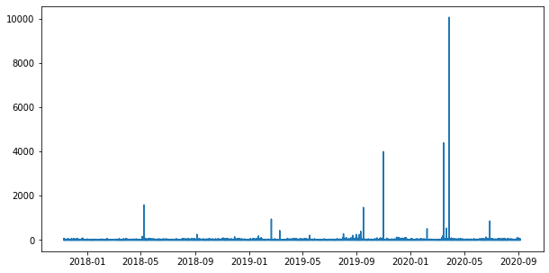

```python
from pylab import rcParams
rcParams['figure.figsize'] = 10,5
x = df['date']
y = df['sales']
plt.plot(x,y)
```

H0: The Null Hypothesis: It is a statement about the population that either is believed to be true or it is used to put forth an argument unless it can be shown to be incorrect beyond a reasonable doubt

H1: The alternative hypothesis: It is a claim about the population that is contradictory to H0 and what we conclude when we reject H0

*H0: it is non-stationary* *H1: it is stationary*

We will be considering the null hypothesis that data is not stationary and the alternative hypothesis that data is stationary

```python
from statsmodels.tsa.stattools import adfuller
```

```python
def adfuller_test(sales):
    result=adfuller(sales)
    labels = ['ADF Test Statistic','p-value','#Lags Used','Number of Observations']
    for value,label in zip(result,labels):
        print(label+' : '+str(value) )

    if result[1] <= 0.05:
        print("strong evidence against the null hypothesis(Ho), reject the null hypothesis. Data is stationary")
    else:
        print("weak evidence against null hypothesis,indicating it is non-stationary ")
```

*Note: I cannot run the **adfuller_test(df['sales'])** function as I do not have enough memory on my computer to do so*

```python
df_samp = df.sample(20000)

adfuller_test(df_samp['sales'])
```

```
ADF Test Statistic : -141.0573423186624
p-value : 0.0
#Lags Used : 0
Number of Observations : 19999
strong evidence against the null hypothesis(Ho), reject the null hypothesis. Data is stationary
```

**The numbers are obviously just fillers for an example's sake**

```python
df['Sales First Difference'] = df['sales'] - df['sales'].shift(1)
df['Seasonal First Difference']=df['sales']-df['sales'].shift(12)
df[['date','sales','Sales First Difference','Seasonal First Difference']].head()
```

|  | date | sales | Sales First Difference | Seasonal First Difference |
| --- | --- | --- | --- | --- |
| 0 | 2017-11-08 | 2.59 | NaN | NaN |
| 1 | 2017-11-08 | 3.98 | 1.39 | NaN |
| 2 | 2017-11-08 | 1.00 | -2.98 | NaN |
| 3 | 2017-11-08 | 1.69 | 0.69 | NaN |
| 4 | 2017-11-08 | 4.50 | 2.81 | NaN |

```python
df_samp = df.sample(20000)

adfuller_test(df_samp['Seasonal First Difference'])
```

```
ADF Test Statistic : -141.243416855858
p-value : 0.0
#Lags Used : 0
Number of Observations : 19999
strong evidence against the null hypothesis(Ho), reject the null hypothesis. Data is stationary
```

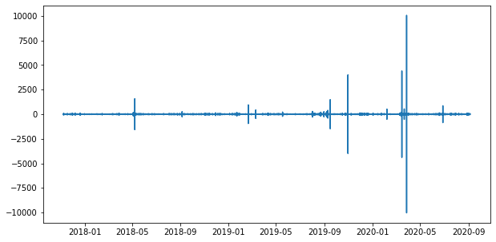

```python
x = df['date']
y = df['Seasonal First Difference']
rcParams['figure.figsize'] = 10,5

plt.plot(x,y)
```

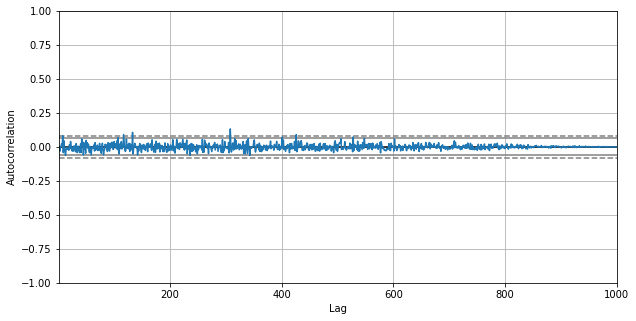

```python
from pandas.plotting import autocorrelation_plot
df_samp = df.sample(1000)
autocorrelation_plot(df_samp['sales'])
rcParams['figure.figsize'] = 10,5
plt.show()
```

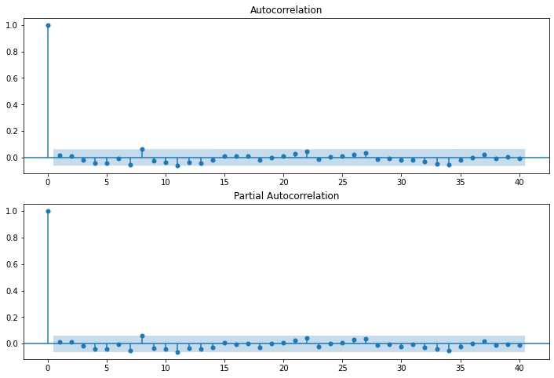

```python
from statsmodels.graphics.tsaplots import plot_acf,plot_pacf
import statsmodels.api as sm
fig = plt.figure(figsize=(12,8))
ax1 = fig.add_subplot(211)
fig = sm.graphics.tsa.plot_acf(df_samp['Seasonal First Difference'].dropna(),lags=40,ax=ax1)
ax2 = fig.add_subplot(212)
fig = sm.graphics.tsa.plot_pacf(df_samp['Seasonal First Difference'].dropna(),lags=40,ax=ax2)
```

```python
# For non-seasonal data
#p=1, d=1, q=0 or 1

from statsmodels.tsa.arima_model import ARIMA
model=ARIMA(df_samp['sales'],order=(1,1,1))
model_fit=model.fit()
model_fit.summary()
```

ARIMA Model Results

| Dep. Variable: | D.sales | No. Observations: | 999 |
| --- | --- | --- | --- |
| Model: | ARIMA(1, 1, 1) | Log Likelihood | -2590.267 |
| Method: | css-mle | S.D. of innovations | 3.223 |
| Date: | Fri, 26 Mar 2021 | AIC | 5188.535 |
| Time: | 16:06:27 | BIC | 5208.162 |
| Sample: | 1 | HQIC | 5195.995 |

|  | coef | std err | z | P>\|z\| | [0.025 | 0.975] |
| --- | --- | --- | --- | --- | --- | --- |
| const | -4.795e-05 | 0.000 | -0.138 | 0.891 | -0.001 | 0.001 |
| ar.L1.D.sales | -0.0137 | 0.032 | -0.432 | 0.666 | -0.076 | 0.048 |
| ma.L1.D.sales | -1.0000 | 0.003 | -349.460 | 0.000 | -1.006 | -0.994 |

Roots

|  | Real | Imaginary | Modulus | Frequency |
| --- | --- | --- | --- | --- |
| AR.1 | -73.1806 | +0.0000j | 73.1806 | 0.5000 |
| MA.1 | 1.0000 | +0.0000j | 1.0000 | 0.0000 |

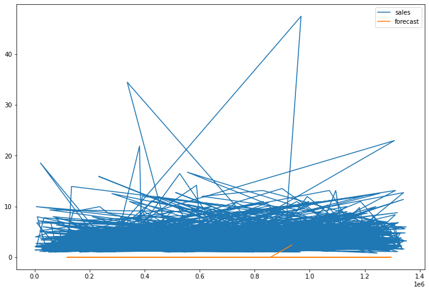

```python
df_samp['forecast']=model_fit.predict(start=90,end=103,dynamic=True)
df_samp[['sales','forecast']].plot(figsize=(12,8))
```

```python
from pandas.tseries.offsets import DateOffset

future_dates=[df.index[-1]+ DateOffset(months=x)for x in range(0,24)]
future_datest_df=pd.DataFrame(index=future_dates[1:],columns=df.columns)

future_datest_df.tail()

future_df=pd.concat([df,future_datest_df])

future_df['forecast'] = results.predict(start = 104, end = 120, dynamic= True)
future_df[['sales', 'forecast']].plot(figsize=(12, 8))
```

[output not shown]